# R Independent Study

Enxhi Xhindoli

04/29/2019

In this report, a logistic regression was constructed in order to obtain the likelihood of an account churning based off variables utilized within the model. The logistic regression allows to assess the churn likelihood of pre-existing accounts.

## Data Collection

The telecomunication company provided the LSU team with different datasets about demographics and rate changes. For the scope of this project, only a subset of the whole dataset was used. The variable BAN_SEQ is the ID which identifies a unique customer.

```r
RCU <- read.csv(here('Data', 'RateChangeUnique.csv'),sep =",", header = TRUE)
DEMO <- read.csv(here('Data', 'DEMO.csv'), sep =",", header=TRUE)
DF <- full_join(DEMO,RCU, by = "BAN_SEQ")
```

### Scraping

In order to add some information about the income, a table containing the average income per state was brought from the website into the Global Environment of Rstudio.

```r
income <- read_html("https://www.infoplease.com/business-finance/poverty-and-income/capita-personal-income-state")%>%
  html_node(css = "#A0104653")%>%
  html_table()
```

For the purpose of this project, only the column showing the average income of each state in 2015 was kept.

```r
income <- as_tibble(income)
income <- select(income, State,`2015`)
income[1:3,]
```

```
## # A tibble: 3 x 2
##   State   `2015`
##   <chr>   <chr>
## 1 Alabama $38,965
## 2 Alaska  55,940
## 3 Arizona 39,060
```

To change the format of the values in this column, as they need to be homogeneous, stringr package was used.

```r
income <- income %>%
  mutate(`2015`=str_extract_all(`2015`,"[0-9]+"))%>%
  mutate(`2015`=map_chr(`2015`,paste,collapse=""))

income <- as.data.frame(income)
names(income)[names(income) == "2015"] <- "AVG_INCOME_2015"
names(income)[names(income) == "State"] <- "STATE"
```

In the dataset provided by the company, the states are represented only with their abbreviation. Therefore, another table, - containing the states and their abbreviations,- was extracted from the following website. The table included also the Commonwealth territories which were dropped from the dataset.

```r
states <- read_html("https://www.50states.com/abbreviations.htm") %>%
  html_node("[class='spaced stripedRows']")%>%
  html_table()

states <- as.data.frame(states)
states <- states[-(51:67),]

names(states)[names(states) == "US State:"] <- "STATE"
names(states)[names(states) == "Abbreviation:"] <- "STATE_ABBREVIATION"
colnames(states)
```

```
## [1] "STATE"              "STATE_ABBREVIATION"
```

At this point, the two tables were merged by the column “STATE”.

```r
Income_per_state <- merge(states,income,by="STATE")
head(Income_per_state)
```

```
##        STATE STATE_ABBREVIATION AVG_INCOME_2015
## 1    Alabama                 AL           38965
## 2     Alaska                 AK           55940
## 3    Arizona                 AZ           39060
## 4   Arkansas                 AR           39107
## 5 California                 CA           52651
## 6   Colorado                 CO           50410
```

Finally, to create the final dataset, this table was merged with the csv dataset provided by the company.

```r
names(DF)[names(DF) == "STATE"] <- "STATE_ABBREVIATION"
DF1 <- left_join(DF,Income_per_state, by = "STATE_ABBREVIATION")
```

## Data preparation

For the purpose of this analysis, only the subset of the observations belonging to the year 2015 will be considered. Because R recognizes SNAPSHOT_DATE as a factor,first it needs to be converted to a character, and then to a date.

```r
DF1$SNAPSHOT_DATE <- as.character(DF1$SNAPSHOT_DATE)
DF1$SNAPSHOT_DATE <- as.Date(DF1$SNAPSHOT_DATE, format = "%m/%d/%Y")
```

```r
DF2 <-DF1 %>%
  filter(SNAPSHOT_DATE>'2014-12-31' & SNAPSHOT_DATE<'2016-01-31')

length(unique(DF2$SNAPSHOT_DATE))
```

```
## [1] 12
```

```r
unique(DF2$SNAPSHOT_DATE)
```

```
##  [1] "2015-04-30" "2015-01-31" "2015-07-31" "2015-06-30" "2015-05-31"
##  [6] "2015-10-31" "2015-12-31" "2015-03-31" "2015-02-28" "2015-08-31"
## [11] "2015-09-30" "2015-11-30"
```

From the dataset, it can be clearly seen that the variable CVGENDERCODE1, which is showing the gender, has more than two occurrences. For practical reasons, the name of the column was first changed, and some inspections about it were made.

```r
names(DF2)[names(DF2) == "CVGENDERCODE1"] <- "GENDER"
DF2$GENDER <- as.character(DF2$GENDER)
unique(DF2$GENDER)
```

```
## [1] "M"    "U"    "F"    "null" NA
```

```r
DF2$GENDER <- revalue(DF2$GENDER, c("U"=NA))
DF2$GENDER <- revalue(DF2$GENDER, c("null"=NA))
count(DF2$GENDER=='NA')
```

[output not shown]

Inspections were made also for the variable EDUCATIONAL_LEVEL.

```r
unique(DF2$EDUCATION_LEVEL)
```

```
## [1] 5    2    4    7    #N/D 1    3    6    <NA>
## Levels: #N/D 1 2 3 4 5 6 7
```

```r
DF2$EDUCATION_LEVEL <- revalue(DF2$EDUCATION_LEVEL, c("#N/D"=NA))
```

To see how the customer’s paying rate has changed a new variable was created as difference between CURR_PAYING_RATE and PRIOR_PAYING_RATE.

Given the definition of customer churn as *“Customers who stopped using company’s product or service during a certain time frame”*, for the creation of variable “CHURN” the CURR_QTY and PRIOR_QTY were taken into consideration. The two variables refer respectively to the current and prior quantity of products purchased by the single customer.

```r
DF3$CHURN <- ifelse(DF3$CURR_QTY >= DF3$PRIOR_QTY,0,1)
```

To make this analysis even more dynamic, the binary variable NEW_CUST was created. As the name reveals, it shows whether a person is a new customer in 2015 or not.

```r
DF3$NEW_CUST <- if_else(DF3$CURR_QTY > 0 & DF3$PRIOR_QTY == 0,1,0)
DF3$NEW_CUST <- factor(DF3$NEW_CUST)
```

## Visualization

The first graph shows the trend of the number of customers and how many of those customers are “new customers” joining the company.

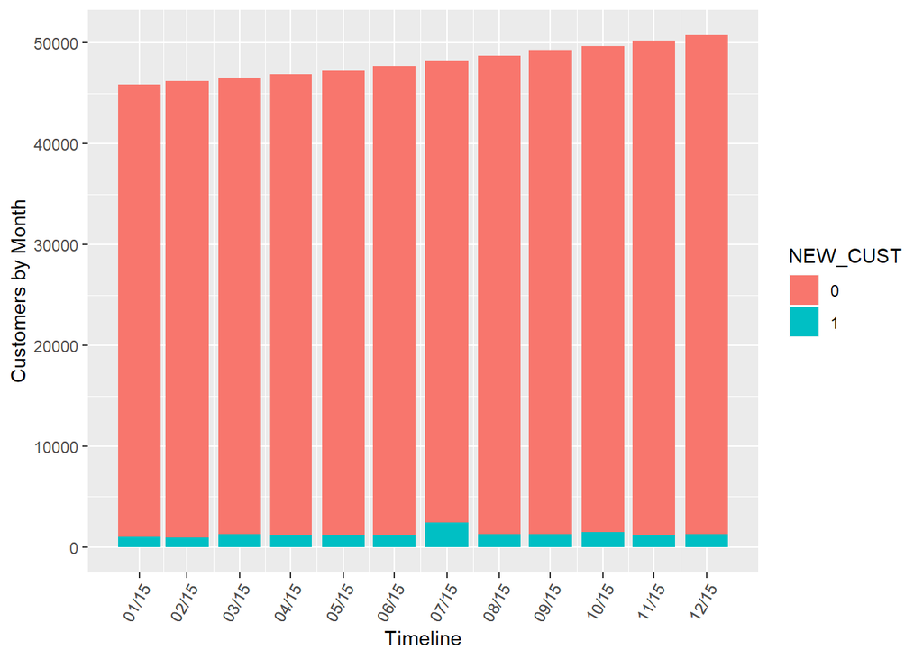

To see in which state the company has the highest number of customers,a barchart was used.

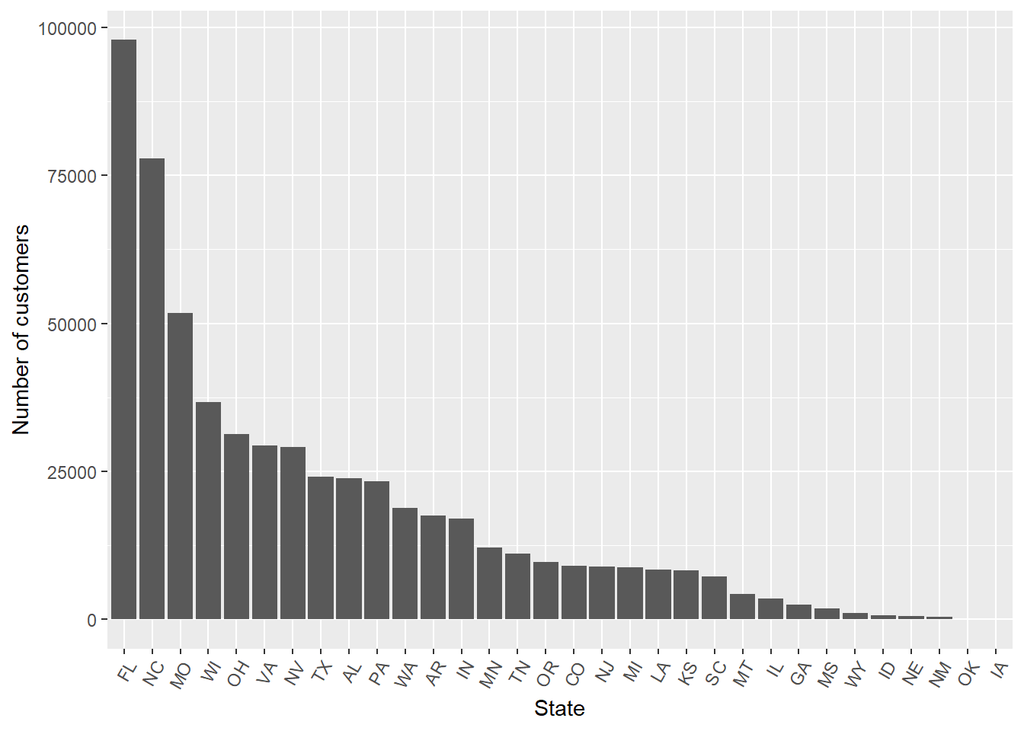

```r
ggplot(V1,
       aes(x=reorder(STATE_ABBREVIATION,STATE_ABBREVIATION,
                     function(x)-length(x)))) + geom_bar()+
  theme(axis.text.x=element_text(angle=60, hjust=1)) +
  xlab("State") + ylab("Number of customers")
```

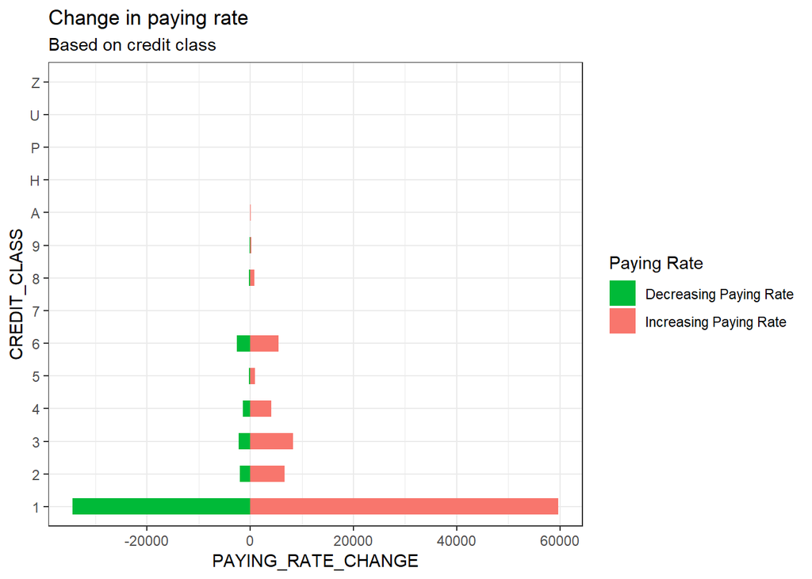

```r
theme_set(theme_bw())

V1$PAYING_RATE <- ifelse(V1$PAYING_RATE_CHANGE < 0, "decrease", "increase")
V1 <- V1[order(V1$PAYING_RATE_CHANGE), ]  # sort
V1$CREDIT_CLASS <- factor(V1$CREDIT_CLASS)  # convert to factor to retain sorted order in plot.

# Diverging Barcharts
ggplot(V1, aes(x=CREDIT_CLASS, y=PAYING_RATE_CHANGE, label=PAYING_RATE_CHANGE)) +
  geom_bar(stat='identity', aes(fill=PAYING_RATE), width=.5)  +
  scale_fill_manual(name="Paying Rate",
                    labels = c("Decreasing Paying Rate", "Increasing Paying Rate"),
                    values = c("decrease"="#00ba38", "increase"="#f8766d")) +
  labs(subtitle="Based on credit class",
       title= "Change in paying rate") +
  coord_flip()
```

Furthermore, we want se see the correlation between the change in paying rate and the number of calls.

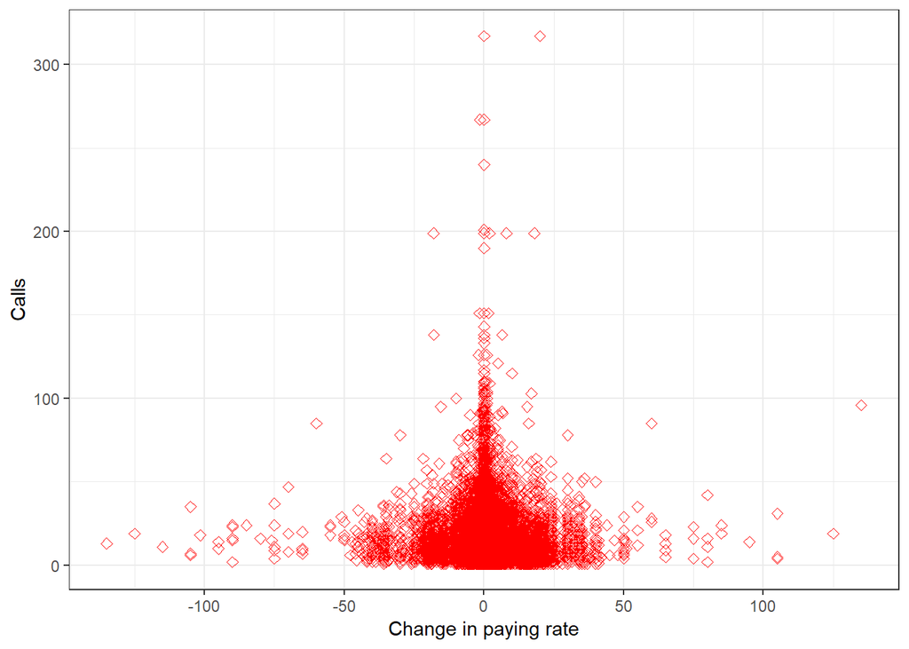

As we can see from the graph, most of the calls are distributed around the interval [-50;50] of the PAYING_RATE_CHANGE, and most of the customers have a range of calls between 0 and 100. However, there are also some outliers as it can be seen from the graph above.

## Builging a Logistic Regression model to predict CHURN

The objective of the Churn predictive model is to assign to the customers a measure of the propensity to abandonment (called score). However, before building a model, it is necessary to see how many instances of CHURN there are in the dataset.

```r
table(DF3$CHURN)
```

```
##
##      0      1
## 697007   9204
```

```r
DF4 <- na.omit(DF3)
# Split the data into training and test set
set.seed(123)
training.samples <- DF4$CHURN %>%
  createDataPartition(p = 0.7, list = FALSE)
train.data  <- DF4[training.samples, ]
test.data <- DF4[-training.samples, ]
# imbalance on training set
table(train.data$CHURN)
```

```
##
##      0      1
## 398775   5334
```

```r
# balanced data set with under-sampling
data.balanced.under <- ovun.sample(CHURN~CREDIT_CLASS+NEW_CUST+CALL_COUNT+AGE+GENDER+EDUCATION_LEVEL+AVG_INCOME_2015, data=train.data, p=0.25, seed=1, method="under")$data
table(data.balanced.under$CHURN)
```

```
##
##     0     1
## 15964  5334
```

Now a logistic regression model is created based on training balanced data.

```
##
## Call:
## glm(formula = CHURN ~ CREDIT_CLASS + NEW_CUST + CALL_COUNT +
##     GENDER + EDUCATION_LEVEL + AVG_INCOME_2015, family = binomial,
##     data = data.balanced.under)
##
## Deviance Residuals:
##     Min       1Q   Median       3Q      Max
## -3.5356  -0.7453  -0.6597   0.3385   1.8933
##
## Coefficients:
##                    Estimate Std. Error z value Pr(>|z|)
## (Intercept)      -1.633e+00  2.294e-01  -7.120 1.08e-12 ***
## CREDIT_CLASS2     4.022e-01  8.804e-02   4.568 4.92e-06 ***
## CREDIT_CLASS3     3.302e-01  7.808e-02   4.229 2.35e-05 ***
## CREDIT_CLASS4     3.197e-01  9.267e-02   3.449 0.000562 ***
## CREDIT_CLASS5     7.324e-01  2.133e-01   3.434 0.000596 ***
## CREDIT_CLASS6     1.467e-01  7.262e-02   2.020 0.043384 *
## CREDIT_CLASS7    -1.502e+01  2.400e+03  -0.006 0.995005
## CREDIT_CLASS8     1.205e+00  2.154e-01   5.594 2.22e-08 ***
## CREDIT_CLASS9     1.994e-02  2.549e-01   0.078 0.937660
## CREDIT_CLASSA    -7.103e-01  5.062e-01  -1.403 0.160522
## CREDIT_CLASSH     1.953e-01  1.160e+00   0.168 0.866321
## CREDIT_CLASSP     1.677e+01  2.400e+03   0.007 0.994423
## CREDIT_CLASSU    -1.502e+01  1.200e+03  -0.013 0.990008
## CREDIT_CLASSZ     1.156e+00  1.420e+00   0.814 0.415403
## NEW_CUST1        -2.073e+01  1.184e+02  -0.175 0.860977
## CALL_COUNT        3.937e-02  1.488e-03  26.467  < 2e-16 ***
## GENDERM          -2.439e-02  3.394e-02  -0.719 0.472391
## EDUCATION_LEVEL2  1.662e-01  1.396e-01   1.191 0.233782
## EDUCATION_LEVEL3  7.239e-02  5.338e-01   0.136 0.892122
## EDUCATION_LEVEL4  1.319e-01  1.362e-01   0.969 0.332723
## EDUCATION_LEVEL5  6.286e-02  1.311e-01   0.480 0.631566
## EDUCATION_LEVEL6  1.264e-01  2.269e-01   0.557 0.577352
## EDUCATION_LEVEL7  2.294e-01  2.030e-01   1.130 0.258475
## AVG_INCOME_2015  -3.208e-07  4.059e-06  -0.079 0.936997
## ---
## Signif. codes:  0 '***' 0.001 '**' 0.01 '*' 0.05 '.' 0.1 ' ' 1
##
## (Dispersion parameter for binomial family taken to be 1)
##
##     Null deviance: 23974  on 21297  degrees of freedom
## Residual deviance: 22756  on 21274  degrees of freedom
## AIC: 22804
##
## Number of Fisher Scoring iterations: 15
```

The model was then applied to the test data.

```
##
## Call:
## accuracy.meas(response = test.data$CHURN, predicted = probabilities)
##
## Examples are labelled as positive when predicted is greater than 0.5
##
## precision: 0.034
## recall: 0.056
## F: 0.021
```

Finally, as it can be clearly seen from the results, this model is not at all accurated. This makes sense as the demographic data was collected from third parties, and therefore built upon many assumptions, but also because it is hard to predict whether a customer will churn or not based on their gender, education level, or similar.